# IODS course project

Ian_Ocholla

# Introduction to Open Data Science - Course Project

# About the project

*Write a short description about the course and add a link to your GitHub repository here. This is an R Markdown (.Rmd) file so you should use R Markdown syntax.*

### How are you *feeling* right now?

I am excited to have enrolled **Open Data Science**

### What do you expect to **learn?**

I look forward to learn

- Data analysis
- Prediction

#### Where did you hear about the course?

My github [link](https://github.com/Ian-ocholla)

```r
# This is a so-called "R chunk" where you can write R code.

date()
```

```
## [1] "Mon Nov 22 07:19:58 2021"
```

The text continues here.

# Regression and model validation

*Describe the work you have done this week and summarize your learning.*

- Describe your work and results clearly.
- Assume the reader has an introductory course level understanding of writing and reading R code as well as statistical methods.
- Assume the reader has no previous knowledge of your data or the more advanced methods you are using.

## Introduction to the data

In this work space, a student feedback data(more information here) collected between 2014-2015 was used to asses the relationship between learning approaches and the students achievement in an introductory statistics course. The dataset underwent [data wrangling analysis](https://github.com/Ian-ocholla/R_source) and will be used to develop a linear regression model and interpret the results.

### 1. Load the data into your Rworkspace from your work directory

The first step to creating a work directory where we have stored our data

```r
#set the working directory of your R session the IODS project folder
setwd("C:/LocalData/ocholla/IODS-project")
```

We load the dataset from the folder saved from Data wrangling exercise.We read the file adding that the header= TRUE and stringAsFactors=TRUE to ensure that the factor variables are not displayed as strings.

```r
students2014<-read.csv("Data/learning2014.csv", header = TRUE, stringsAsFactors = TRUE)
```

### 2. Data exploration and analysis

We explore the data structure and its dimensions

```r
str(students2014)
```

```
## 'data.frame':    166 obs. of  7 variables:
##  $ gender  : Factor w/ 2 levels "F","M": 1 2 1 2 2 1 2 1 2 1 ...
##  $ age     : int  53 55 49 53 49 38 50 37 37 42 ...
##  $ attitude: num  3.7 3.1 2.5 3.5 3.7 3.8 3.5 2.9 3.8 2.1 ...
##  $ deep    : num  3.5 3.1 3.5 3.5 3.7 4.7 3.7 3.1 4.3 4 ...
##  $ stra    : num  3.38 2.75 3.62 3.12 3.62 ...
##  $ surf    : num  2.58 3.17 2.25 2.25 2.83 ...
##  $ points  : int  25 12 24 10 22 21 21 31 24 26 ...
```

```r
dim(students2014)
```

```
## [1] 166   7
```

The data contains 166 observations of 7 variables. The observations refers to the students and the variables refer to student gender (male or female), age (derived the date of birth), exam points, attitude, deep learning (deep), strategic learning (stra) and surface learning (surf).

#### Summaries of the variables in the data

```r
summary(students2014)
```

```
##  gender       age           attitude          deep            stra
##  F:110   Min.   :17.00   Min.   :1.400   Min.   :1.600   Min.   :1.250
##  M: 56   1st Qu.:21.00   1st Qu.:2.600   1st Qu.:3.300   1st Qu.:2.625
##          Median :22.00   Median :3.200   Median :3.700   Median :3.188
##          Mean   :25.51   Mean   :3.143   Mean   :3.666   Mean   :3.121
##          3rd Qu.:27.00   3rd Qu.:3.700   3rd Qu.:4.100   3rd Qu.:3.625
##          Max.   :55.00   Max.   :5.000   Max.   :4.900   Max.   :5.000
##       surf           points
##  Min.   :1.583   Min.   : 7.00
##  1st Qu.:2.417   1st Qu.:19.00
##  Median :2.833   Median :23.00
##  Mean   :2.787   Mean   :22.72
##  3rd Qu.:3.167   3rd Qu.:27.75
##  Max.   :4.333   Max.   :33.00
```

The mean age of the students in the class is 25 years, with the youngest being 17 years while the oldest at 55 years. The attitude variable was scaled to 1-5, with good attitude was rated at 5.  
Female students were almost twice more than the male students in the course, with deep learning having the highest mean value among the three variables. The lowest exam point attained by the students was 7 with the overall class having an average of 22.

#### Graphical Visualizing of student attitude aganist exam points

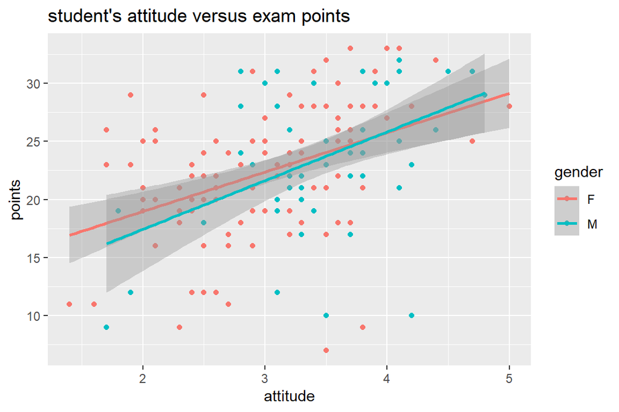

```r
library(ggplot2)
#initialize plot with data and aesthetic mapping
p1<- ggplot(students2014, aes( x= attitude, y= points, col = gender))
#define the visualization type (points)
p2<- p1 + geom_point()
#add a regression line
p3<- p2+geom_smooth(method = "lm")
#add a main title and draw the plot
p4<- p3 + ggtitle("student's attitude versus exam points")
p4
```

From the plot above, we can deduce that majority of student across both gender had average attitude which coinciding with attaining average exam points. Female students with a negative attitude towards statistics managed to get higher exam points compared to male students with negative attitude.

#### An advanced plot matrix with ggpairs()

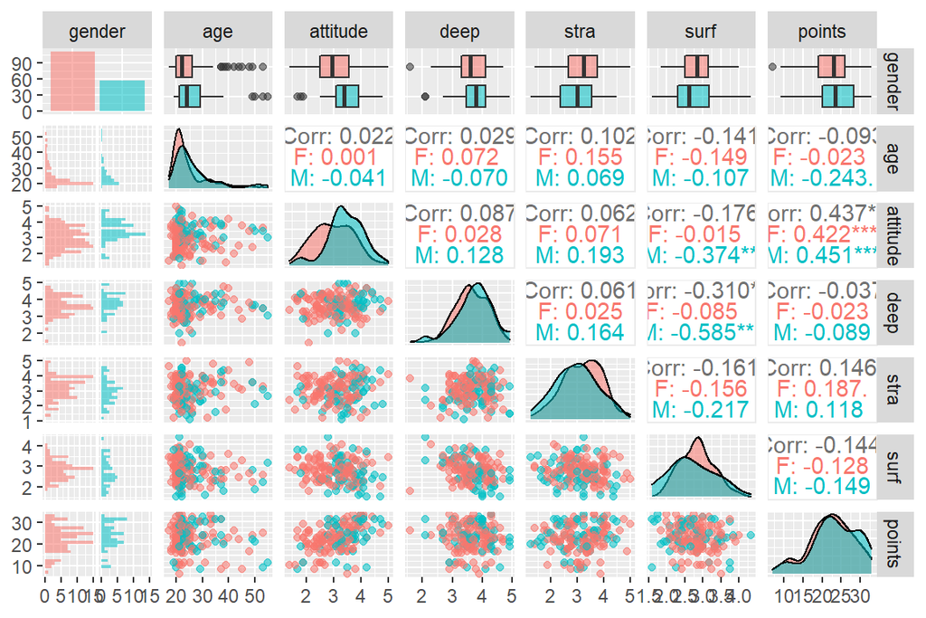

```r
#Access the GGally and ggplot2 libraries
library(GGally)
#create a more advanced plot matrix with ggpairs()
p<- ggpairs(students2014, mapping = aes (col = gender, alpha = 0.3), lower = list(combo = wrap("facethist", bins = 20)))
#draw the plot
p
```

From the scatter plot, across both gender the attitude of the student is highly correlated to the exam points attained. While there is higher likelihood of male students failing in deep learning compared to female students

### 3.Regression model

Linear regression model is a statistical approach that is used for modelling relationships between a dependent variable **y** and one or more explanatory variables **X**. If there is only one explanatory variable then its called simple linear regression while in more than one variable it is referred as multiple linear regression.
Linear model is divided into two parts namely systematic and stochastic parts. The model follows the equation below
$$Y \sim \propto + X\beta_1+X\beta_2.....\beta_k +\epsilon$$

- where **Y** is the target variable, we wish to predict the values of **y** using the values of **X**
- $\propto+X\beta_0+X\beta_1$ is the systematic part of the model
- $\beta$ quantifies the relationship between **y** and **x**.
- $\epsilon$ describes the errors, which is assumed to be normally distributed.

```r
my_model<- lm(points~ attitude+stra+age, data = students2014)
summary(my_model)
```

```
##
## Call:
## lm(formula = points ~ attitude + stra + age, data = students2014)
##
## Residuals:
##      Min       1Q   Median       3Q      Max
## -18.1149  -3.2003   0.3303   3.4129  10.7599
##
## Coefficients:
##             Estimate Std. Error t value Pr(>|t|)
## (Intercept) 10.89543    2.64834   4.114 6.17e-05 ***
## attitude     3.48077    0.56220   6.191 4.72e-09 ***
## stra         1.00371    0.53434   1.878   0.0621 .
## age         -0.08822    0.05302  -1.664   0.0981 .
## ---
## Signif. codes:  0 '***' 0.001 '**' 0.01 '*' 0.05 '.' 0.1 ' ' 1
##
## Residual standard error: 5.26 on 162 degrees of freedom
## Multiple R-squared:  0.2182, Adjusted R-squared:  0.2037
## F-statistic: 15.07 on 3 and 162 DF,  p-value: 1.07e-08
```

The **call formula** captures the model fitted, e.g. in this case it is a multilinear regression with points as target variables while attitude, strategic learning and age are the independent variables.

**Residuals** Residuals are the difference between the actual observed response value (exam points) and the response values that the model predicted.  
The residual section is divided into 5 summary points, and it is used to assess how symmetrical distribution of the model across the points on the mean value zero. From the analysis, we can see the distribution of the residual appear abit symmetrical.

**Coefficients**  
Coefficient gives unknown constants that represent the *intercept* and *unknown parameters* in terms of the model. Under the coefficient section , there are four variables.

1. *Estimate* The coefficient Estimate contains four rows ; the first one is the intercept $\propto$ value, while the rest correspond to estimates of the unknown parameters $\beta_1+\beta_2 ....\beta_k$ in our multi linear regression model.
2. *Coefficient -Standard error*  
   The coefficient Standard Error measures the average amount that the coefficient estimates vary from the actual average value of the response variable (exam points). Ideally, this value should be lower than its coefficient.
3. *Coefficient-t value* The coefficient t-vale is a measure of how many standard deviations our coefficient estimate is far from 0. When the t-value is far from zero, this would indicate that we can reject the null hypothesis, that is, we declare there relationship between the dependent variables and the target variable exist.In our analysis, the t-statistic value of *attitude* is relatively far away from zero and is larger relative to the standard error, which would indicate a relationship exist, compared to variables *stra* and *age*.
4. *Coefficient -Pr(<t)* Commonly referred to as the p-value, a small p-vale indicates that it is unlikely to observe a relationship between the predictors and the target variable due to chance. Typically, a p-value of 5% or less is a good cut -off point. In our model, the p-vales for *intercept* and *attitude* are more closer to zero compared to *stra* and *age*.

**Residual standard error** is a measure of the quality of a linear regression fit. The residual standard error is the average amount that the response (exam points) will deviate from the true regression line.In *my_model* the response *exam points* deviated from the true regression line by approximately 5.26 on average. Note that the Residual Standard Error was calculated with 162 degrees of freedom (DOF). DOF are the number of data points that went into the estimation of the parameters used after taking into account these parameters. In this analysis, we had 166 observation (students), intercept and three predictors parameters.

**Multiple R-squared**  
The R-squared also known as coefficient of determination ($R^2$) statistics provides the percentage of the variation within the dependent/response/target variable that the independent variables are explaining.In other word, it describes how well the model is fitting the data. $R^2$ always lies between 0 and 1, with values approaching 0 indicating a regression that does not explain the variance in the response variable well, while a value closer to 1 explains the variance in the response variable).In *my_model*, the $R^2$ is 21.82%, meaning that only 22% of the variance found in the response variable (exam point) can be explained by the predictors *attitude, stra and age*. Adjusted R-squared is shows what percentage of the variation within the dependent variable that all predictors are explaining.

### 4. Diagnostic plots

Three diagnostic plots were plotted from the model

1. Residual Vs Fitted
   This plot explores the validity of the model assumptions that are included in the expression
   $$\epsilon \sim N(0,\sigma^2)$$
- The errors are normally distributed
- The errors are not correlated
- The errors have constant variance $\sigma^2$
- The size of a given error does not depend on the explanatory variables
2. Normal Q-Q plot  
   Explores the assumption that the errors of the model are normally distributed.When the majority of the residual are falling along the line, then it validates the assumption of normality. Severe deviation of the residuals from the normal line makes the assumption of normality questionable.
3. Residual vs Leverage plot  
   Leverage measures how much impact or influence a single observation has on the model. Not all outliers are influential in regression analysis.Cases which have high influence are usually located at the upper right corner or at the lower right corner. Presence of cases is such spots can be influential against a regression line.When cases are outside the Cook’s distance, meaning they have high Cook’s distance scores) , the cases are influential to the regression results, and the regression results will be altered if they are excluded.

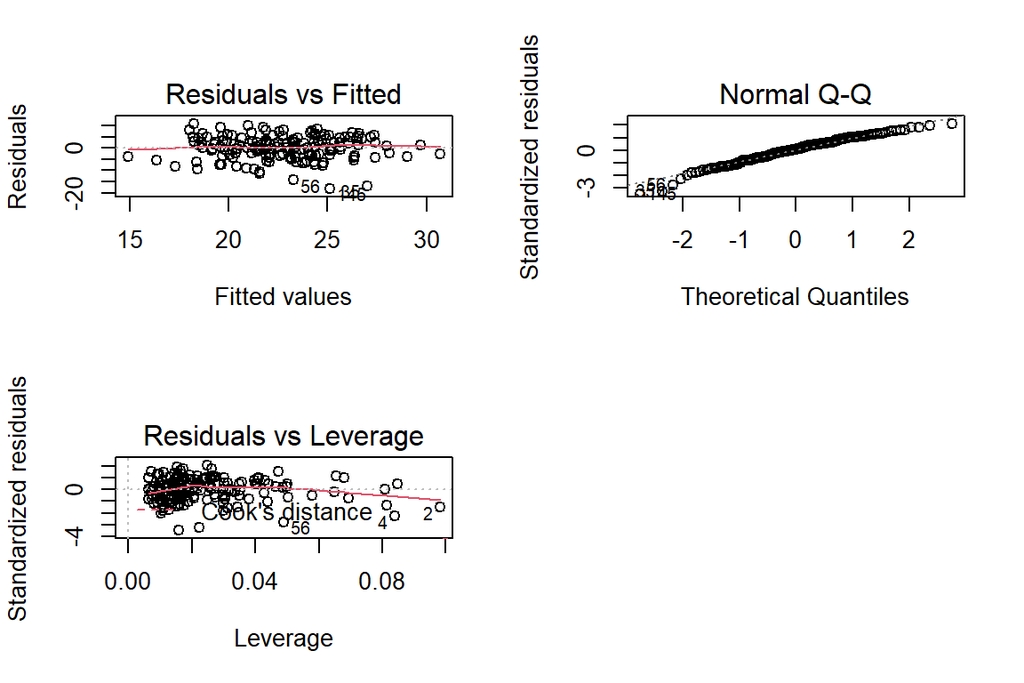

```r
par(mfrow= c(2,2))
plot(my_model, which = c(1,2,5))
```

In the **Residual vs Fitted** plot, the residual are distributed without following a distinctive pattern indicating that the linear relation ship was explained by the model.

In the **Normal Q-Q plot**, most of the residual points are falling along the diagonal line, with little deviation at both ends.Since there is minimal deviation of the residuals from the line, the QQ plot strengthens the assumption of normality of the model

In the **leverage plot** there are no influential cases as we can see the Cook’s distance as all the cases are well inside of the Cook’s distance lines.

```r
date()
```

```
## [1] "Mon Nov 22 07:20:08 2021"
```

References  
1. [Rmarkdown for Scientist](https://rmd4sci.njtierney.com)  
2. [University of Virginia Library](https://data.library.virginia.edu/diagnostic-plots/)

# LOGISTIC REGRESSION ANALYSIS

In this exercise, we explore the use of **logistic regression analysis** on student achievement data in secondary education in two Portuguese schools. The data attribute include the student grades, demographic, social and school related features. The data was collected by using school reports and questionnaires. More information can be found in the [link](https://archive.ics.uci.edu/ml/datasets/Student+Performance)

Purpose of the analysis is to study the relationships between high/low alcohol consumption and students attributes. The *joined dataset* used in the analysis exercise combines the two student alcohol consumption data sets. The following adjustment have been made;

- ‘alc_use is the average of ’Dalc’ and ‘Walc’
- ‘high_use’ is true if ‘alc_use’ is higher than 2 and FALSE otherwise

### 1. Load and describe the student alcohol consumption data

```r
#set the work directory
setwd("C:/LocalData/ocholla/IODS-project")
#Load the data
alc<- read.csv("Data/pormath.csv", header = TRUE, stringsAsFactors = TRUE)
#print column names
colnames(alc)
```

```
##  [1] "school"     "sex"        "age"        "address"    "famsize"
##  [6] "Pstatus"    "Medu"       "Fedu"       "Mjob"       "Fjob"
## [11] "reason"     "guardian"   "traveltime" "studytime"  "schoolsup"
## [16] "famsup"     "activities" "nursery"    "higher"     "internet"
## [21] "romantic"   "famrel"     "freetime"   "goout"      "Dalc"
## [26] "Walc"       "health"     "n"          "id.p"       "id.m"
## [31] "failures"   "paid"       "absences"   "G1"         "G2"
## [36] "G3"         "failures.p" "paid.p"     "absences.p" "G1.p"
## [41] "G2.p"       "G3.p"       "failures.m" "paid.m"     "absences.m"
## [46] "G1.m"       "G2.m"       "G3.m"       "alc_use"    "high_use"
## [51] "cid"
```

```r
#structure of the data
str(alc)
```

```
## 'data.frame':    370 obs. of  51 variables:
##  $ school    : Factor w/ 2 levels "GP","MS": 1 1 1 1 1 1 1 1 1 1 ...
##  $ sex       : Factor w/ 2 levels "F","M": 1 1 1 1 1 1 1 1 1 1 ...
##  $ age       : int  15 15 15 15 15 15 15 15 15 15 ...
##  $ address   : Factor w/ 2 levels "R","U": 1 1 1 1 1 1 1 1 1 2 ...
##  $ famsize   : Factor w/ 2 levels "GT3","LE3": 1 1 1 1 1 1 1 2 2 1 ...
##  $ Pstatus   : Factor w/ 2 levels "A","T": 2 2 2 2 2 2 2 2 2 1 ...
##  $ Medu      : int  1 1 2 2 3 3 3 2 3 3 ...
##  $ Fedu      : int  1 1 2 4 3 4 4 2 1 3 ...
##  $ Mjob      : Factor w/ 5 levels "at_home","health",..: 1 3 1 4 4 4 4 2 3 3 ...
##  $ Fjob      : Factor w/ 5 levels "at_home","health",..: 3 3 3 2 4 2 5 4 3 2 ...
##  $ reason    : Factor w/ 4 levels "course","home",..: 2 4 4 1 4 1 1 4 4 4 ...
##  $ guardian  : Factor w/ 3 levels "father","mother",..: 2 2 2 2 3 2 1 2 1 1 ...
##  $ traveltime: int  2 1 1 1 2 1 2 2 2 1 ...
##  $ studytime : int  4 2 1 3 3 3 3 2 4 4 ...
```

[output cut: 37 more lines]

The dataset contains 370 observation of 51 variables, the variables are a mixture of integers, factors and logical data types

### 2. Analysis of student variables relationship with alcohol consumption.

Hypothesis on the four variables

1. sex- male students consume higher alcohol compared to female students
2. studytime- low study time among the students increase the chances for high use of alcohol
3. famrel- Good quality family relationship reduces alcohol abuse.
4. goout- students who have a high tendency of going out with friends are prone to peer pressure which can easily lead to high alcohol consumption

**Distribution of alcohol consumption by gender**

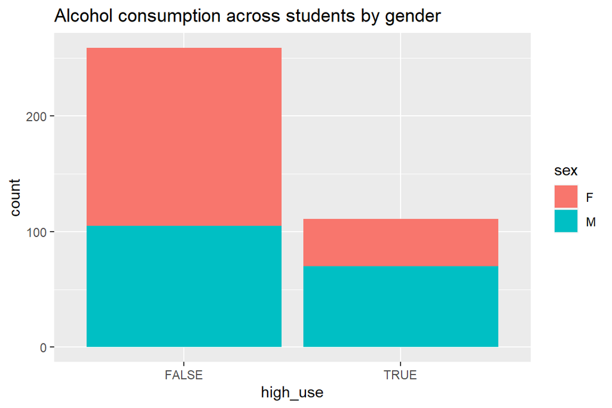

```r
library(ggplot2)
g1<- ggplot(data= alc, aes(x = high_use, fill= sex))
#define the plot as a bar plot and draw it
g1+ geom_bar()+ ggtitle("Alcohol consumption across students by gender")
```

High proportion of male students indulge in high alcohol consumption compared to female students, whereas, more female student population consume low alcohol in comparison to the male student with low alcohol intake.

**Relationship between sex, quality family relationships and use of alcohol**

```r
#*summary statistics by sex and quality family relationships
library(dplyr)
```

```r
library(ggplot2)

#produce summary statistics by group
alc%>% group_by(sex, high_use)%>% summarise(count= n(), familytime=mean(famrel))
```

```
## # A tibble: 4 x 4
## # Groups:   sex [2]
##   sex   high_use count familytime
##   <fct> <lgl>    <int>      <dbl>
## 1 F     FALSE      154       3.92
## 2 F     TRUE        41       3.73
## 3 M     FALSE      105       4.13
## 4 M     TRUE        70       3.79
```

Four-fifth of all the female students have low alcohol consumption and they have higher mean in the quality of family relationship compared to female students who had high alcohol consumption. Similarly, male students with high family relationship had low alcohol consumption.

**Relationship between sex and incidences of going out with alcohol consumption among the students**

```r
#*failures
alc%>% group_by(sex, high_use)%>% summarise(count= n(), going_out=mean(goout))
```

```
## # A tibble: 4 x 4
## # Groups:   sex [2]
##   sex   high_use count going_out
##   <fct> <lgl>    <int>     <dbl>
## 1 F     FALSE      154      2.95
## 2 F     TRUE        41      3.39
## 3 M     FALSE      105      2.70
## 4 M     TRUE        70      3.93
```

In both genders, higher incidences of going out are associated with high consumption of alcohol

**Does high use of alcohol have a connection to study time?**

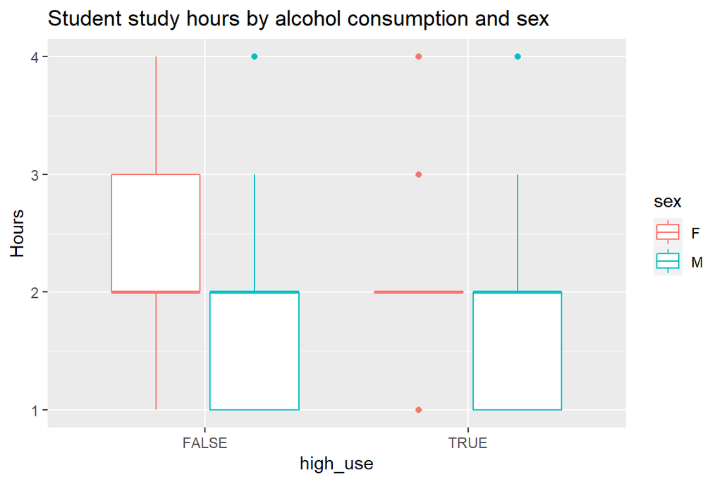

```r
#does high use of alcohol have a connection to romantic relationship?
a2<- ggplot(alc, aes(x= high_use, y = studytime, col= sex))
#define the plot as a boxplot and draw it
a2 + geom_boxplot()+ylab("Hours")+ggtitle("Student study hours by alcohol consumption and sex")
```

Among students with low alcohol consumption, the female students spent between 5 to 10 hours in their studies compared to male students who spent between 3-5 hours.

On the contrary, female students with high alcohol consumption spent exactly 5 hours for their studies while the make students spent 2 to 5 hours.

## 3. Fitting a logistics model

```r
#find the model with glm()
m<- glm(high_use~sex+studytime+famrel+goout, data = alc, family = "binomial")
#print out a summary of the model
summary(m)
```

```
##
## Call:
## glm(formula = high_use ~ sex + studytime + famrel + goout, family = "binomial",
##     data = alc)
##
## Deviance Residuals:
##     Min       1Q   Median       3Q      Max
## -1.5891  -0.7629  -0.4976   0.8304   2.6937
##
## Coefficients:
##             Estimate Std. Error z value Pr(>|z|)
## (Intercept)  -1.2672     0.7312  -1.733  0.08309 .
## sexM          0.7959     0.2669   2.982  0.00286 **
## studytime    -0.4814     0.1711  -2.814  0.00490 **
## famrel       -0.4193     0.1399  -2.996  0.00273 **
## goout         0.7873     0.1230   6.399 1.57e-10 ***
## ---
## Signif. codes:  0 '***' 0.001 '**' 0.01 '*' 0.05 '.' 0.1 ' ' 1
##
## (Dispersion parameter for binomial family taken to be 1)
##
##     Null deviance: 452.04  on 369  degrees of freedom
## Residual deviance: 370.69  on 365  degrees of freedom
## AIC: 380.69
##
## Number of Fisher Scoring iterations: 4
```

From the model, the p-values for the four variables are statistically significant. The output supports the hypothesis that gender, study time, going out and quality family relationship affects the student’s alcohol consumption. The positive estimate value on the factor variable sex indicates likelihood of high use of alcohol among male students with reference to the female students

**Model coefficients**

```r
#Print out the coefficients of the model
coef(m)
```

```
## (Intercept)        sexM   studytime      famrel       goout
##  -1.2672175   0.7959494  -0.4813712  -0.4192830   0.7872896
```

Based on the regression coefficients, the odds of high use of alcohol increased with students being male and those with a high frequency of going out, while it decreased with in students who allocate more study time and have excellent family relationships. **Odd ratio** Odd ratio is the ratio of expected “successes” to failures.Higher odds corresponds to a higher probability of success, with the value ranging from zero to infinity.

Transform the coefficients to odds ratios and transform it by exponentiation it to return it as a unit change in the predictor variable (*high_use*), holding all other predictor variables constant

```r
#compute odds ratios (OR)
OR<- coef(m)%>% exp
#compute confidence intervals (CI)
CI<- confint(m)%>% exp
#Print out te odds ratios with their CI
cbind(OR,CI)
```

```
##                    OR      2.5 %    97.5 %
## (Intercept) 0.2816141 0.06545486 1.1622100
## sexM        2.2165443 1.31841735 3.7630180
## studytime   0.6179355 0.43751933 0.8576353
## famrel      0.6575181 0.49791884 0.8636137
## goout       2.1974324 1.73873662 2.8198312
```

**Predictive power of the model** Exploring the predictive power of the logistic model, through a 2x2 cross tabulation of predictors versus the actual values.

```r
#predict() the probability of high_use
probabilities <- predict(m, type = "response")
#add the predicted probabilities to alc
alc<- mutate(alc, probability= probabilities)
#use the probabilities to make a prediction of high_use
alc<- mutate(alc, prediction= probability>0.5)
#*see the first five original classes, predicted probabilities,
select(alc, goout, famrel,studytime, sex, high_use,probability, prediction)%>% head(5)
```

```
##   goout famrel studytime sex high_use probability prediction
## 1     2      3         4   F    FALSE  0.05335420      FALSE
## 2     4      3         2   F     TRUE  0.41613728      FALSE
## 3     1      4         1   F    FALSE  0.06670564      FALSE
## 4     2      4         3   F    FALSE  0.05657850      FALSE
## 5     1      4         3   F     TRUE  0.02656662      FALSE
```

The chances of high alcohol consumption declines when the student is female

**Confusion matrix (2x2) table**

```r
#tabulate the target variable versus the predictions

table(high_use=alc$high_use, prediction=alc$prediction)
```

```
##         prediction
## high_use FALSE TRUE
##    FALSE   230   29
##    TRUE     59   52
```

From the table, 230 low alcohol consumption was corrected while 29 were incorrectly predicted. on the other hand, 52 observation of high alcohol consumption were correctly predicted while 59 were wrongly predicted.

plotting the original *high_use* versus the predicted in alc

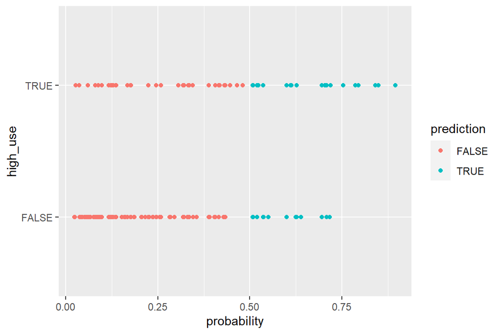

```r
#initialize a plot of 'high_use' versus 'probability' in alc
g<- ggplot(alc, aes(x = probability, y= high_use, col = prediction))
#define the geom as points and draw the plot
g+geom_point()
```

**Accuracy assessment through the confusion matrix**

```r
#tabulate the target variable versus the predictions
table(high_use = alc$high_use, prediction = alc$prediction)%>% prop.table%>% addmargins
```

```
##         prediction
## high_use      FALSE       TRUE        Sum
##    FALSE 0.62162162 0.07837838 0.70000000
##    TRUE  0.15945946 0.14054054 0.30000000
##    Sum   0.78108108 0.21891892 1.00000000
```

Approximately 19% and 36% were inaccurately predicted for the false and true values respectively by the model.  
From the confusion matrix table, the accuracy of the prediction can be calculated through addition of True Negative and Positive (0.62 and 0.14) divided by the summation of both true and false values in both the original set (high_use) and prediction. we get that the prediction accuracy is 0.76, this is a high performance from the model compared to simple guessing strategies.

### 4. Cross validation

This is a method of testing a predictive model on unseen data split the data into training and testing data, whereby the training data is used to find the model while the test data is used to make prediction and evaluate the model performance

One round of cross validation involves

1. partitioning a sample of data into complementary subsets
2. Performing the analysis on one subset (the training set, larger)
3. validating the analysis on the other subset (the testing set, smaller)

This process is repeated so that eventually all of the data is used for both training and testing.In CV, the value of a penalty(loss) function (mean prediction error) is computed on data not used for finding the model. A low CV value is an indication of a good model.

**Cross validation using 10 K-folds**

```r
library(boot)
#define a loss function (average prediction error)
loss_func<- function(class, prob){
  n_wrong<-abs(class - prob)> 0.5
  mean(n_wrong)
}
#average number of wrong prediction
loss_func(class = alc$high_use, prob = alc$probability)
```

```
## [1] 0.2378378
```

```r
cv<- cv.glm(data= alc, cost= loss_func, glmfit= m, K=10)
#average number of wrong predictions in the cross validation
cv$delta[1]
```

```
## [1] 0.2540541
```

```r
#find the model with glm()
summary(m0<- glm(high_use~G3+absences+traveltime+reason+famsize+sex+studytime+famrel+goout, data = alc, family = "binomial"))
```

```
##
## Call:
## glm(formula = high_use ~ G3 + absences + traveltime + reason +
##     famsize + sex + studytime + famrel + goout, family = "binomial",
##     data = alc)
##
## Deviance Residuals:
##     Min       1Q   Median       3Q      Max
## -1.8894  -0.7459  -0.4418   0.6426   2.7811
##
## Coefficients:
##                  Estimate Std. Error z value Pr(>|z|)
## (Intercept)      -2.66560    1.00389  -2.655  0.00792 **
## G3               -0.01447    0.04251  -0.340  0.73350
## absences          0.07678    0.02339   3.282  0.00103 **
## traveltime        0.40320    0.19364   2.082  0.03732 *
## reasonhome        0.34770    0.34200   1.017  0.30930
## reasonother       1.11530    0.46975   2.374  0.01759 *
## reasonreputation -0.16462    0.36307  -0.453  0.65025
## famsizeLE3        0.23888    0.29336   0.814  0.41549
## sexM              0.87539    0.28243   3.100  0.00194 **
## studytime        -0.30531    0.18219  -1.676  0.09379 .
## famrel           -0.42737    0.14738  -2.900  0.00373 **
## goout             0.78725    0.13037   6.039 1.55e-09 ***
## ---
## Signif. codes:  0 '***' 0.001 '**' 0.01 '*' 0.05 '.' 0.1 ' ' 1
##
## (Dispersion parameter for binomial family taken to be 1)
##
##     Null deviance: 452.04  on 369  degrees of freedom
## Residual deviance: 346.82  on 358  degrees of freedom
## AIC: 370.82
##
## Number of Fisher Scoring iterations: 5
```

```r
summary(m1<- glm(high_use~absences+traveltime+reason+sex+studytime+famrel+goout, data = alc, family = "binomial"))
```

```
##
## Call:
## glm(formula = high_use ~ absences + traveltime + reason + sex +
##     studytime + famrel + goout, family = "binomial", data = alc)
##
## Deviance Residuals:
##     Min       1Q   Median       3Q      Max
## -1.9077  -0.7427  -0.4506   0.6514   2.7420
##
## Coefficients:
##                  Estimate Std. Error z value Pr(>|z|)
## (Intercept)      -2.74054    0.85222  -3.216 0.001301 **
## absences          0.07805    0.02326   3.356 0.000791 ***
## traveltime        0.41779    0.19046   2.194 0.028263 *
## reasonhome        0.32961    0.34063   0.968 0.333226
## reasonother       1.09017    0.46850   2.327 0.019970 *
## reasonreputation -0.18187    0.36148  -0.503 0.614869
## sexM              0.89451    0.28156   3.177 0.001488 **
## studytime        -0.32030    0.18031  -1.776 0.075671 .
## famrel           -0.43481    0.14668  -2.964 0.003033 **
## goout             0.79177    0.12892   6.142 8.16e-10 ***
## ---
## Signif. codes:  0 '***' 0.001 '**' 0.01 '*' 0.05 '.' 0.1 ' ' 1
##
## (Dispersion parameter for binomial family taken to be 1)
##
##     Null deviance: 452.04  on 369  degrees of freedom
## Residual deviance: 347.54  on 360  degrees of freedom
## AIC: 367.54
##
## Number of Fisher Scoring iterations: 5
```

```r
summary(m2<- glm(high_use~absences+traveltime+sex+studytime+famrel+goout, data = alc, family = "binomial"))
```

```
##
## Call:
## glm(formula = high_use ~ absences + traveltime + sex + studytime +
##     famrel + goout, family = "binomial", data = alc)
##
## Deviance Residuals:
##     Min       1Q   Median       3Q      Max
## -1.7951  -0.7373  -0.4716   0.6918   2.5876
##
## Coefficients:
##             Estimate Std. Error z value Pr(>|z|)
## (Intercept) -2.35248    0.80844  -2.910  0.00362 **
## absences     0.07725    0.02257   3.423  0.00062 ***
## traveltime   0.37496    0.18585   2.018  0.04364 *
## sexM         0.89229    0.27716   3.219  0.00128 **
## studytime   -0.38722    0.17561  -2.205  0.02745 *
## famrel      -0.41690    0.14401  -2.895  0.00379 **
## goout        0.76216    0.12560   6.068 1.29e-09 ***
## ---
## Signif. codes:  0 '***' 0.001 '**' 0.01 '*' 0.05 '.' 0.1 ' ' 1
##
## (Dispersion parameter for binomial family taken to be 1)
##
##     Null deviance: 452.04  on 369  degrees of freedom
## Residual deviance: 355.05  on 363  degrees of freedom
## AIC: 369.05
##
## Number of Fisher Scoring iterations: 4
```

```r
date()
```

```
## [1] "Mon Nov 22 07:20:10 2021"
```

(more chapters to be added similarly as we proceed with the course!)